# HW_STATA_Mukimova_Alina

#### Однажды в Самарканде турист заказывал Яндекс-такси. На десятом заказе впервые приехал таксист, который уже раньше приезжал к туристу. Для упрощения предположим, что все n таксистов Самарканда всегда на работе и приезжают равновероятно.

а) [5] Постройте график функции правдоподобия как функции от общего количества такси n. Найдите оценку числа n методом максимального правдоподобия.

Вероятность того, что к туристу в Самарканде приедет впервые таксист, который уже раньше его возил:

P = n/n *(n-1)/n* (n-2)/n *...* (n-8)/n *9/n Получается: P = n!*9/(n-9)!n***10

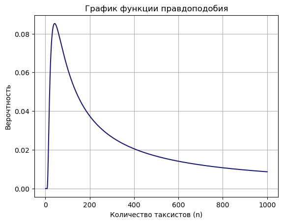

```python
import numpy as np
import matplotlib.pyplot as plt

def likelihood(n):
    p = 1.0
    for i in range(9):
        p *= (n - i) / n
    p *= 9/n
    return p

n_values = np.arange(1, 1001)

likelihood_values = [likelihood(n) for n in n_values]
estimated_n = n_values[np.argmax(likelihood_values)]

plt.plot(n_values, likelihood_values, color='midnightblue')
plt.xlabel('Количество таксистов (n)')
plt.ylabel('Верочтность')
plt.title('График функции правдоподобия')
plt.grid(True)
plt.show()
```

```python
# Найдем оценку числа n методом максимального правдоподобия
n_ml = np.argmax(likelihood_values)+1
print('ML оценка n = ', n_ml)
```

```
ML оценка n =  42
```

б) [5] Постройте график математического ожидания номера заказа, на котором происходит первый повторный приезд, как функции от общего количества такси n. Найдите оценку числа n методом моментов.

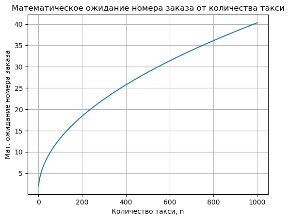

```python
import numpy as np
import matplotlib.pyplot as plt

def expected_order(n):
    expected = 0.0
    for i in range(2, n+2):
        p = 1
        for j in range(i-1):
            p *= (n - j) / n
        expected += i*(i-1)*p/n
    return expected

n_values = np.arange(1, 1001)
expected_values = [expected_order(n) for n in n_values]

plt.plot(n_values, expected_values)
plt.xlabel('Количество такси, n')
plt.ylabel('Мат. ожидание номера заказа')
plt.title('Математическое ожидание номера заказа от количества такси')
plt.grid(True)
plt.show()
```

```python
n_MM = expected_values.index(min(expected_values, key=lambda x: abs(x - 10))) + 1

print(f'MM оценка для количества таксистов = {n_MM}')
```

```
MM оценка для количества таксистов = 55
```

в) Предположим, что настоящее n равно 100. Проведя 10000 симуляций вызовов такси до первого повторного, рассчитайте 10000 оценок методом моментов и 10000 оценок ме- тодом максимального правдоподобия. Постройте гистограммы для оценок двух методов. Оцените смещение, дисперсию и среднеквадратичную ошибку двух методов.

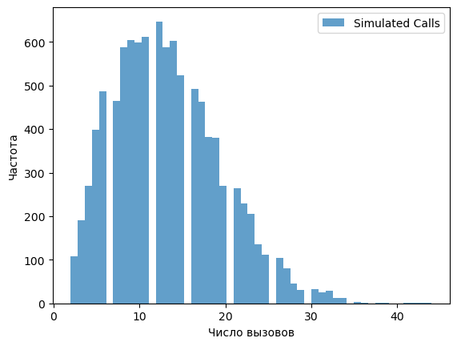

```
Метод моментов:
Смещение: -86.76859999999999
Дисперсия: 39.08705404
MSE: 7567.876999999999

Метод максимального правдоподобия:
Смещение: -95.52780982782393
Дисперсия: 39.08705404
MSE: 9164.649504540894
```

```python
import numpy as np
import matplotlib.pyplot as plt

def simulate_calls(n, num_simulations):
    calls_to_repeat = []
    for _ in range(num_simulations):
        drivers = set()
        calls = 0
        while True:
            calls += 1
            driver = np.random.randint(1, n + 1)
            if driver in drivers:
                calls_to_repeat.append(calls)
                break
            drivers.add(driver)
    return calls_to_repeat

n = 100
num_simulations = 10000
calls_to_repeat = simulate_calls(n, num_simulations)

moments_estimate = np.mean(calls_to_repeat)
likelihood_estimate = np.log(n) + np.log(1 - 1 / n) * np.mean(calls_to_repeat)

true_value = n
bias_moments = moments_estimate - true_value
bias_likelihood = likelihood_estimate - true_value

variance_moments = np.var(calls_to_repeat)
variance_likelihood = np.var(calls_to_repeat)

mse_moments = bias_moments**2 + variance_moments
mse_likelihood = bias_likelihood**2 + variance_likelihood

plt.hist(calls_to_repeat, bins='auto', alpha=0.7, label='Simulated Calls')
plt.xlabel('Число вызовов')
plt.ylabel('Частота')
plt.legend()
plt.show()

print("Метод моментов:")
print("Смещение:", bias_moments)
print("Дисперсия:", variance_moments)
print("MSE:", mse_moments)
print()
print("Метод максимального правдоподобия:")
print("Смещение:", bias_likelihood)
print("Дисперсия:", variance_likelihood)
print("MSE:", mse_likelihood)
```

Что-то не так, как будто((

# Task 2

#### Однажды в Самарканде турист заказывал Яндекс-такси. На десятом заказе он обнаружил, что у таксистов было 6 разных имён. Для упрощения предположим, что все n имён среди таксистов встречаются равновероятно и независимо от поездки к поездке.

а) Постройте график функции правдоподобия как функции от общего количества имён n. Найдите оценку числа n методом максимального правдоподобия.

[figure not shown]

```python
image_path = "/Users/linalalan/Downloads/photo_2023-06-11_22-57-02 (2).jpg"
image = Image.open(image_path)

display(image)
```

```python
from scipy.optimize import minimize

def likelihood(n, k, m):
    return ((n - k) / n) ** m

def maximize_likelihood(k, m):
    objective = lambda x: -likelihood(x[0], k, m)  # Минус, так как используем minimize
    initial_guess = [k+2]  # Начальное приближение для оптимизации
    bounds = [(k, None)]  # Ограничение на значение n (k и больше)
    result = minimize(objective, initial_guess, bounds=bounds)
    return result.x[0]

k = 6  # количество разных имен
m = 10  # общее количество поездок

estimated_n = maximize_likelihood(k, m)
print(f"Оценка числа n: {estimated_n}")
```

```
Оценка числа n: 8.0
```

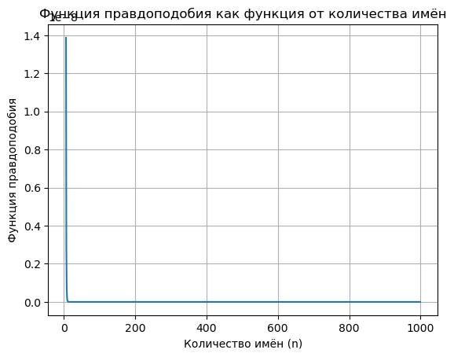

```python
def likelihood(n):
    likelihood_value = 0
    for k in range(1, 11):
        likelihood_value += comb(10, k) * (1/(n+1e-10))**k * (1-1/(n+1e-10))**(10-k) * (1/(n+1e-10)**10)
    return likelihood_value

# comb(10, k) - вычисляет количество возможных комбинаций из 10 элементов, выбранных k элементами
# (1/(n+1e-10))**k - вероятность того, что конкретное имя встретится k раз среди общего количества поездок m
# (1-1/(n+1e-10) -  вероятность того, что остальные имена (не выбранное конкретное имя) не встретятся среди общего количества поездок m
# (1/(n+1e-10)**10) - вероятность, что каждое из общего количества поездок m будет одним из имён
# Везде, где число/n добавила что-то маленькое: 1e-10, чтобы он не ругался, что я делю на ноль

n_values = np.arange(6, 1000)
likelihood_values = [likelihood(n) for n in n_values]

plt.plot(n_values, likelihood_values)
plt.xlabel('Количество имён (n)')
plt.ylabel('Функция правдоподобия')
plt.title('Функция правдоподобия как функция от количества имён')
plt.grid(True)
plt.show()
```

# Task 3

#### Иноагент Иннокентий по 20 наблюдениям строит 95%-й доверительный интервал для математического ожидания несколькими способами: классический асимптотический нормальный интервал, с помощью наивного бутстрэпа, с помощью бутстрэпа t-статистики.

## A

Для каждого способа с помощью 10000 симуляций оцените вероятность того, что номи- нально 95%-й доверительный интервал фактически накрывает математическое ожидание, если наблюдения распределены экспоненциально с интенсивностью 1.

```python
import numpy as np
from scipy.stats import expon, norm, t
import scipy.stats as sts
```

```python
n_sim = 10000
sample = 20
confidence = 0.95
alpha = 0.05
```

```python
data = expon.rvs(scale=1, size=(n_sim, sample), random_state=42)
```

#### Способ 1: классический асимтотический нормальный интервал

```python
count = 0

#Проходим циклом по всем симуляциям
for i in data:
    mean = np.mean(data, axis=1) #находим среднее
    std = np.std(data, axis=1, ddof=1) / np.sqrt(sample) #находим стандартную ошибку по формуле: std / sqrt(n)
    z_critical = np.abs(norm.ppf((1 - confidence) / 2))
    ci_normal = np.column_stack((mean - z_critical * std, mean + z_critical * std)) #строим ДИ

mu = 1  # Фактическое математическое ожидание

coverage_normal = np.mean((ci_normal[:, 0] <= mu) & (mu <= ci_normal[:, 1]))
print('Вероятность, что 95%-ый доверительный интервал фактически накрывает математическое ожидание: ', round(coverage_normal, 3))
```

```
Вероятность, что 95%-ый доверительный интервал фактически накрывает математическое ожидание:  0.904
```

#### Способ 2: наивный бутстрэп

```python
np.random.seed(42)

# Количество генерируемых бутстрэпом выборок
n_boot = 10000

covering_boot = 0
# Проход циклом по всем симуляциям
for i in data:
    boot_i = np.random.choice(i, size=(n_boot, sample))                                 # Бутстрапируем выборку наблюдений
    boot_i_mean = np.mean(boot_i, axis=1)                                               # Считаем среднее boot выборки
    q_L, q_R = np.quantile(boot_i_mean, alpha/2), np.quantile(boot_i_mean, 1 - alpha/2) # Левый и правый квантили средних
    CI = [q_L, q_R]                                                                     # Итоговый CI для мат. ожидания

    if (CI[0] <= mu) & (mu <= CI[1]):
        covering_boot += 1

print('Вероятность, что 95%-ый доверительный интервал фактически накрывает математическое ожидание:', round(covering_boot/n_boot, 3))
```

```
Вероятность, что 95%-ый доверительный интервал фактически накрывает математическое ожидание: 0.903
```

#### Способ 3: бутстрэп t-статистики

```python
np.random.seed(42)

covering_boot_t = 0

for i in data:
    boot_i = np.random.choice(i, size=(n_boot, len(i)))
    R_boot_t = (np.mean(boot_i, axis=1) - np.mean(i)) / (np.std(boot_i, ddof=1, axis=1) / np.sqrt(len(i)))
    CI_boot_t = [
        np.mean(i) - np.quantile(R_boot_t, 1 - 0.05 / 2) * (np.std(i, ddof=1) / np.sqrt(len(i))),
        np.mean(i) - np.quantile(R_boot_t, 0.05 / 2) * (np.std(i, ddof=1) / np.sqrt(len(i)))
    ]

    if (CI_boot_t[0] <= mu) and (mu <= CI_boot_t[1]):
        covering_boot_t += 1

print('Вероятность, что 95%-ый доверительный интервал фактически накрывает математическое ожидание:',
      round(covering_boot_t / n_boot, 3))
```

```
Вероятность, что 95%-ый доверительный интервал фактически накрывает математическое ожидание: 0.947
```

## Б

Пересчитайте вероятности накрытия, если наблюдения имеют распределение Стьюдента с тремя степенями свободы.

```python
data = t.rvs(df=3, size=(n_sim, sample), random_state=42)
```

#### Способ 1: классический асимтотический нормальный интервал

```python
count = 0

#Проходим циклом по всем симуляциям
for i in data:
    mean = np.mean(data, axis=1) #находим среднее
    std = np.std(data, axis=1, ddof=1) / np.sqrt(sample) #находим стандартную ошибку по формуле: std / sqrt(n)
    z_critical = np.abs(norm.ppf((1 - confidence) / 2))
    ci_normal = np.column_stack((mean - z_critical * std, mean + z_critical * std)) #строим ДИ

mu = 0  # Фактическое математическое ожидание (поменялось, тк распределение Стьюдента)

coverage_normal = np.mean((ci_normal[:, 0] <= mu) & (mu <= ci_normal[:, 1]))
print('Вероятность, что 95%-ый доверительный интервал фактически накрывает математическое ожидание: ',
      round(coverage_normal, 3))
```

```
Вероятность, что 95%-ый доверительный интервал фактически накрывает математическое ожидание:  0.944
```

#### Способ 2: наивный бутстрэп

```python
np.random.seed(42)

# Количество генерируемых бутстрэпом выборок
n_boot = 10000

covering_boot = 0
# Проход циклом по всем симуляциям
for i in data:
    boot_i = np.random.choice(i, size=(n_boot, sample))
    boot_i_mean = np.mean(boot_i, axis=1)
    q_L, q_R = np.quantile(boot_i_mean, alpha/2), np.quantile(boot_i_mean, 1 - alpha/2)
    CI = [q_L, q_R]

    if (CI[0] <= mu) & (mu <= CI[1]):
        covering_boot += 1

print('Вероятность, что 95%-ый доверительный интервал фактически накрывает математическое ожидание:',
          round(covering_boot/n_boot, 3))
```

```
Вероятность, что 95%-ый доверительный интервал фактически накрывает математическое ожидание: 0.919
```

#### Способ 3: бутстрэп t-статистики

```python
np.random.seed(42)

covering_boot_t = 0

for i in data:
    boot_i = np.random.choice(i, size=(n_boot, len(i)))
    R_boot_t = (np.mean(boot_i, axis=1) - np.mean(i)) / (np.std(boot_i, ddof=1, axis=1) / np.sqrt(len(i)))
    CI_boot_t = [
        np.mean(i) - np.quantile(R_boot_t, 1 - 0.05 / 2) * (np.std(i, ddof=1) / np.sqrt(len(i))),
        np.mean(i) - np.quantile(R_boot_t, 0.05 / 2) * (np.std(i, ddof=1) / np.sqrt(len(i)))
    ]

    if (CI_boot_t[0] <= mu) and (mu <= CI_boot_t[1]):
        covering_boot_t += 1

print('Вероятность, что 95%-ый доверительный интервал фактически накрывает математическое ожидание:',
      round(covering_boot_t / n_boot, 3))
```

```
Вероятность, что 95%-ый доверительный интервал фактически накрывает математическое ожидание: 0.923
```

## В

Какой способ оказался лучше?